# penguins-assemble

Alison Hill

6/23/2021

```r
library(tidyverse)
library(palmerpenguins)
```

## Wrangle

`r source("wrangle.R", local = knitr::knit_global())`

`r shrimpiest_penguins`

`## # A tibble: 3 x 2 ## species min_mass ## <fct> <int> ## 1 Adelie 2850 ## 2 Chinstrap 2700 ## 3 Gentoo 3950`

Julie: after you type this bit up, run interactive, then knit

Julie: knit is ugly b/c of messages

Alison: turn off messages for package loading chunk only, then reknit

Alison: can suggest that you echo false and pipe knitr::kable

|species | min_mass| |:———|——–:| |Adelie | 2850| |Chinstrap | 2700| |Gentoo | 3950|

Julie: reknits, tada

## Plot

`r source("plot.R", local = knitr::knit_global())`

`r ggflipper_body`

`## Warning: Removed 2 rows containing missing values (geom_point).`

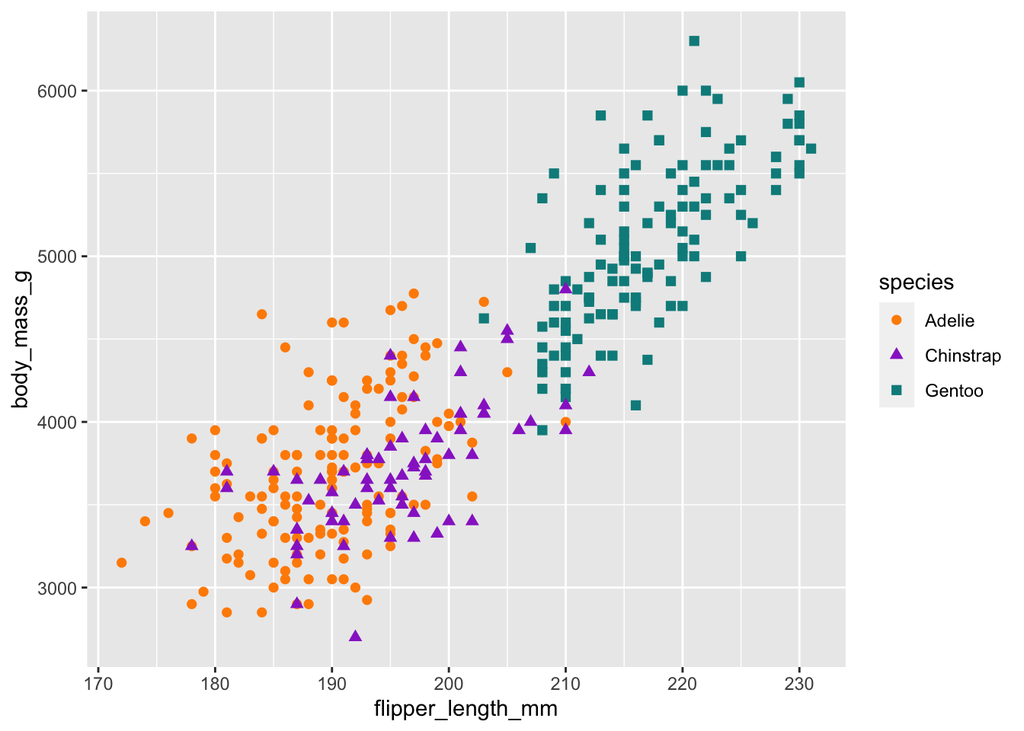

Alison: this motivates a setup chunk, let’s add warning FALSE. you could also do message false there to in the setup to clean up your output

Julie: reknit, oh that is awesome, can you make the name better?

Alison: let’s name that code chunk that makes the figure and see

Julie:

`r ggflipper_body`

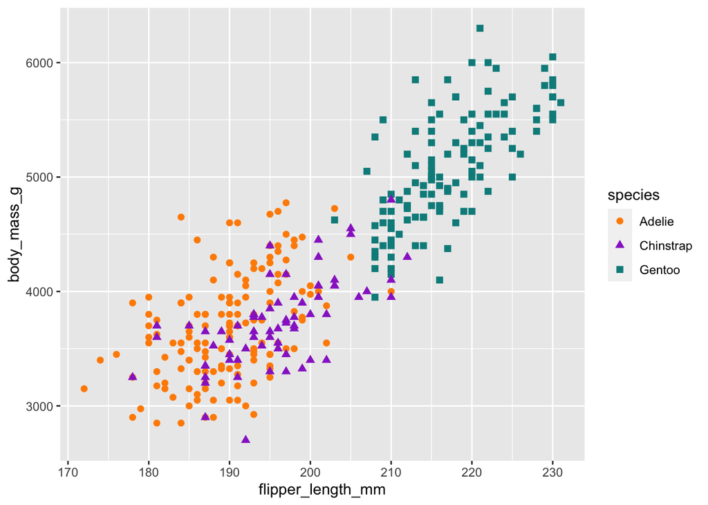

reknit, watch as the figure populates to the new folder also, can point out new thing in drop-down code navigator

Julie: Ok so Alison this is great. If I have a full R script, I can source it.

What if I want to organize

Alison: let’s open up penguins_plots.R and add:

## —- iris-pairs —-

Now you can:

- collapse this code so you can find what you are looking for faster.
- You can also use the drop-down code navigator

```r
knitr::read_chunk("penguins_plots.R")
```

Alison:

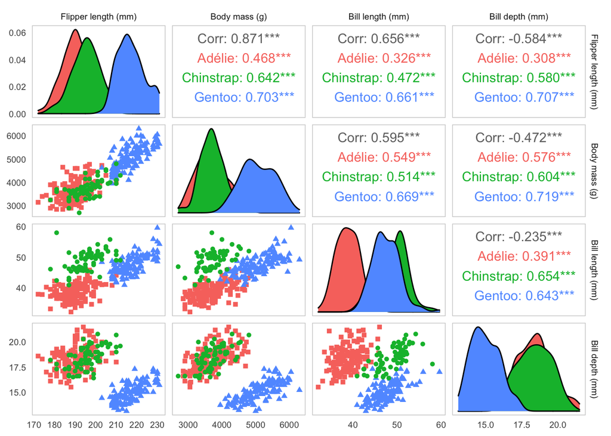

```r
penguins %>%
  mutate(species = as.character(species)) %>%
  mutate(species = case_when(
    species == "Adelie" ~ "Adélie",
    TRUE ~ species
  )) %>%
  select(species, where(is.numeric)) %>%
  GGally::ggpairs(aes(color = species, shape = species),
          columns = c("flipper_length_mm", "body_mass_g",
                      "bill_length_mm", "bill_depth_mm"),
          columnLabels = c("Flipper length (mm)","Body mass (g)", "Bill length (mm)", "Bill depth (mm)")) +
  scale_shape_manual(values = c(15,16,17)) +
  theme_minimal() +
  theme(
        text = element_text(size = 9),
        panel.grid.major = element_line(colour = NA),
        panel.grid.minor = element_blank(),
        panel.border = element_rect(color = "gray80", fill = NA)
        )
```

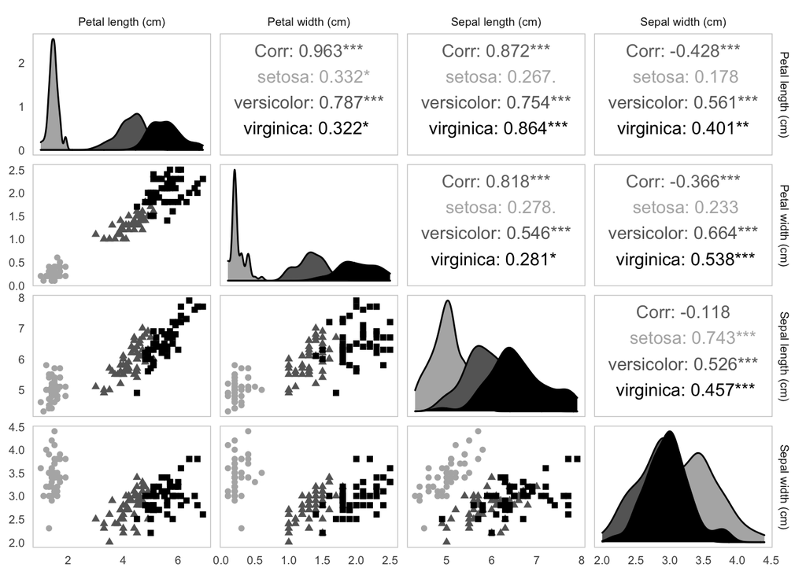

```r
iris %>%
  GGally::ggpairs(aes(color = Species, shape = Species),
          columns = c("Petal.Length", "Petal.Width",
                      "Sepal.Length", "Sepal.Width"),
          columnLabels = c("Petal length (cm)","Petal width (cm)", "Sepal length (cm)", "Sepal width (cm)")) +
  scale_colour_manual(values = c("gray70","gray40","black")) +
  scale_fill_manual(values = c("gray70","gray40","black")) +
  theme_minimal() +
  theme(
        text = element_text(size = 9),
        panel.grid.major = element_line(colour = NA),
        panel.grid.minor = element_blank(),
        panel.background = element_rect(fill = "white", color = "gray80")
        )
```

# Knit Child

NOW I’ve got these other small .Rmds. instead of R scripts

# Artwork

A new way to reuse your code so when you’re developing content for diff audiences: Might always want this in your grant application, or your samples.

Alison: Conditionally including text/some parts of your story.

There’s a lot of other ways to get your code from one file into another, but here we’re also doing it nicely with text. we can also do it with code:

## Simpson’s Paradox

This is important to describe:

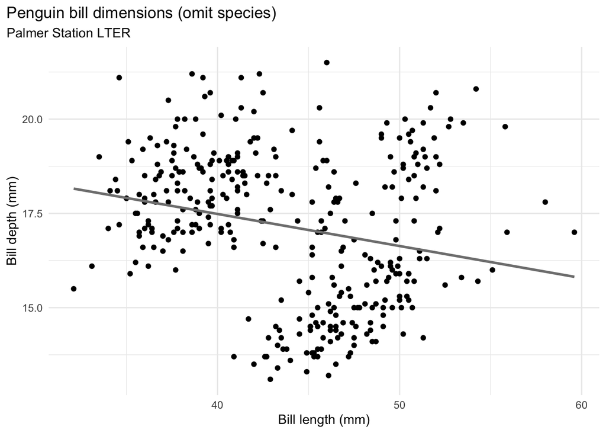

```
#> Warning: Removed 2 rows containing non-finite values (stat_smooth).
#> Warning: Removed 2 rows containing missing values (geom_point).
```

```r
bill_no_species <- ggplot(data = penguins,
                         aes(x = bill_length_mm,
                             y = bill_depth_mm)) +
  geom_point() +
  theme_minimal() +
  scale_color_manual(values = c("darkorange","purple","cyan4")) +
  labs(title = "Penguin bill dimensions (omit species)",
       subtitle = "Palmer Station LTER",
       x = "Bill length (mm)",
       y = "Bill depth (mm)") +
  theme(plot.title.position = "plot",
        plot.caption = element_text(hjust = 0, face= "italic"),
        plot.caption.position = "plot") +
  geom_smooth(method = "lm", se = FALSE, color = "gray50")

bill_no_species
```

Finale: in setup chunk